# Lab 12 Homework

Luc-Tanton Tran

2025-02-22

## Instructions

Answer the following questions and complete the exercises in RMarkdown. Please embed all of your code and push your final work to your repository. Your final lab report should be organized, clean, and run free from errors. Remember, you must remove the `#` for the included code chunks to run. Be sure to add your name to the author header above. For any included plots, make sure they are clearly labeled. You are free to use any plot type that you feel best communicates the results of your analysis.

Make sure to use the formatting conventions of RMarkdown to make your report neat and clean!

## Load the libraries

```r
library(tidyverse)
library(janitor)
library(naniar)
```

```r
options(scipen = 999)
```

## Resources

The idea for this assignment came from [Rebecca Barter’s](http://www.rebeccabarter.com/blog/2017-11-17-ggplot2_tutorial/) ggplot tutorial so if you get stuck this is a good place to have a look.

## Gapminder

For this assignment, we are going to use the dataset [gapminder](https://cran.r-project.org/web/packages/gapminder/index.html). Gapminder includes information about economics, population, and life expectancy from countries all over the world. You will need to install it before use.

```r
#install.packages("gapminder")
library("gapminder")
```

1. Use the function(s) of your choice to get an idea of the overall structure of the data frame, including its dimensions, column names, variable classes, etc. As part of this, determine how NA’s are treated in the data.

*There are 6 columns and 1,704 rows. There are continuous variables, factors, and integers (year). Year may have to be reclassified as a factor so that the bar plots look good. Off cursory glance, there doesn’t seem to be any obvious means of categorizing NAs.*

```r
gapminder <- gapminder
glimpse(gapminder)
```

```
## Rows: 1,704
## Columns: 6
## $ country   <fct> "Afghanistan", "Afghanistan", "Afghanistan", "Afghanistan", …
## $ continent <fct> Asia, Asia, Asia, Asia, Asia, Asia, Asia, Asia, Asia, Asia, …
## $ year      <int> 1952, 1957, 1962, 1967, 1972, 1977, 1982, 1987, 1992, 1997, …
## $ lifeExp   <dbl> 28.801, 30.332, 31.997, 34.020, 36.088, 38.438, 39.854, 40.8…
## $ pop       <int> 8425333, 9240934, 10267083, 11537966, 13079460, 14880372, 12…
## $ gdpPercap <dbl> 779.4453, 820.8530, 853.1007, 836.1971, 739.9811, 786.1134, …
```

```r
summary(gapminder)
```

```
##         country        continent        year         lifeExp
##  Afghanistan:  12   Africa  :624   Min.   :1952   Min.   :23.60
##  Albania    :  12   Americas:300   1st Qu.:1966   1st Qu.:48.20
##  Algeria    :  12   Asia    :396   Median :1980   Median :60.71
##  Angola     :  12   Europe  :360   Mean   :1980   Mean   :59.47
##  Argentina  :  12   Oceania : 24   3rd Qu.:1993   3rd Qu.:70.85
##  Australia  :  12                  Max.   :2007   Max.   :82.60
##  (Other)    :1632
##       pop               gdpPercap
##  Min.   :     60011   Min.   :   241.2
##  1st Qu.:   2793664   1st Qu.:  1202.1
##  Median :   7023596   Median :  3531.8
##  Mean   :  29601212   Mean   :  7215.3
##  3rd Qu.:  19585222   3rd Qu.:  9325.5
##  Max.   :1318683096   Max.   :113523.1
##
```

2. How many countries are represented in this dataset? Make a table and a plot that shows the number of countries by continent.

*There are 142 total countries.There are 52 countries in Africa, 25 in the Americas, 33 in Asia, 30 in Europe, and 2 in Oceania.*

```r
gapminder %>%
  summarize(n_countries = n_distinct(country))
```

```
## # A tibble: 1 × 1
##   n_countries
##         <int>
## 1         142
```

```r
gapminder %>%
  group_by(continent) %>%
  summarize(n_countries = n_distinct(country))
```

```
## # A tibble: 5 × 2
##   continent n_countries
##   <fct>           <int>
## 1 Africa             52
## 2 Americas           25
## 3 Asia               33
## 4 Europe             30
## 5 Oceania             2
```

[figure not shown]

```r
gapminder %>%
  ggplot(aes(x=continent))+
  geom_bar()+
  labs(title = "Number of Countries by Continent",
       x = "Continent",
       y = "Number of Countries")+
  theme(plot.title = element_text(size = rel(2), hjust = 0.5))
```

3. Which country has the largest population growth since 1952? Show this as a table.

```r
gapminder %>%
  group_by(country) %>%
  summarize(
    pop_growth = max(pop)-min(pop),
    log10_pop_growth = log(pop_growth), #for analysis
    .groups='keep'
  ) %>%
  arrange(-pop_growth)
```

```
## # A tibble: 142 × 3
## # Groups:   country [142]
##    country       pop_growth log10_pop_growth
##    <fct>              <int>            <dbl>
##  1 China          762419569             20.5
##  2 India          738396331             20.4
##  3 United States  143586947             18.8
##  4 Indonesia      141495000             18.8
##  5 Brazil         133408087             18.7
##  6 Pakistan       127924057             18.7
##  7 Bangladesh     103561480             18.5
##  8 Nigeria        101912068             18.4
##  9 Mexico          78556574             18.2
## 10 Philippines     68638596             18.0
## # ℹ 132 more rows
```

4. Make a plot that shows population growth for the country you found in question #3. This plot should show the change over time.

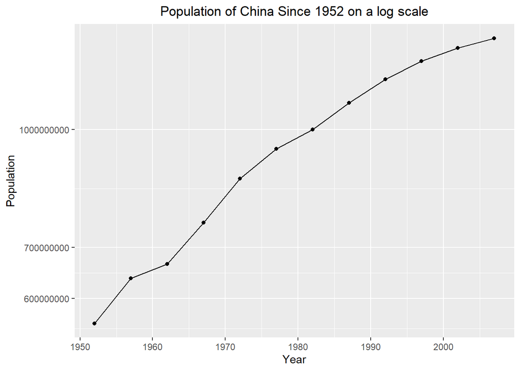

```r
gapminder %>%
  filter(country == "China") %>%
  ggplot(aes(x=year, y = pop))+
  geom_point()+
  geom_line()+
  labs(
    title = "Population of China Since 1952 on a log scale",
    x = "Year",
    y = "Population"
  )+
  scale_y_log10()+ #scaling population to log10
  theme(plot.title = element_text(hjust = 0.5))
```

5. How has global life expectancy changed between 1952 and 2007? Show the min, mean, and max for all countries in the dataset. Show this as a table.

```r
# Min, Mean, Max for each country
gapminder %>%
  group_by(country) %>%
  summarize(
    min_expectancy = min(lifeExp),
    mean_expectancy = mean(lifeExp),
    max_expectancy = max(lifeExp)
  )
```

```
## # A tibble: 142 × 4
##    country     min_expectancy mean_expectancy max_expectancy
##    <fct>                <dbl>           <dbl>          <dbl>
##  1 Afghanistan           28.8            37.5           43.8
##  2 Albania               55.2            68.4           76.4
##  3 Algeria               43.1            59.0           72.3
##  4 Angola                30.0            37.9           42.7
##  5 Argentina             62.5            69.1           75.3
##  6 Australia             69.1            74.7           81.2
##  7 Austria               66.8            73.1           79.8
##  8 Bahrain               50.9            65.6           75.6
##  9 Bangladesh            37.5            49.8           64.1
## 10 Belgium               68              73.6           79.4
## # ℹ 132 more rows
```

6. Make a plot that shows how mean life expectancy has changed over time for each continent. What is your interpretation of what happened in Africa between 1987 and 2002?

*It looks like something happened during that time. From quick googling, it seems that it might be from floods at the time and relatively inaccessible medical services. There’s also a chance it’s because of AIDS.*

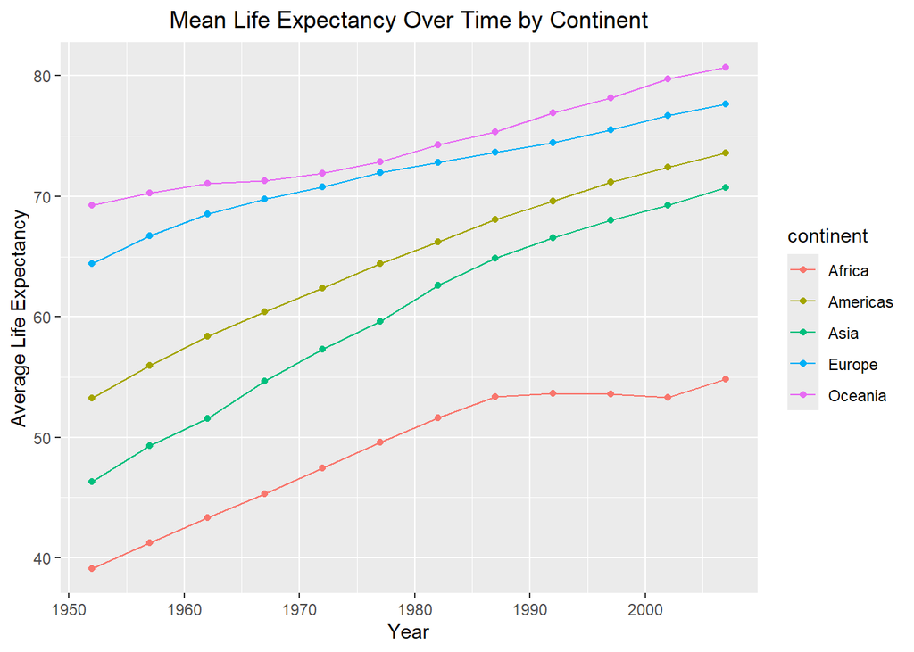

```r
gapminder %>%
  group_by(continent, year) %>%
  mutate(mean_life_exp = mean(lifeExp)) %>%
  ggplot(aes(x = year, y = mean_life_exp, color = continent))+
  geom_point()+
  geom_line()+
  labs(title = "Mean Life Expectancy Over Time by Continent",
       x = "Year",
       y = "Average Life Expectancy")+
  theme(plot.title = element_text(hjust=0.5))
```

7. We are interested in the relationship between per capita GDP and life expectancy; i.e. does having more money help you live longer? Show this as a plot.

*It looks like it helps to a degree, because there’s a general upward trend. It’s very noisy, however.*

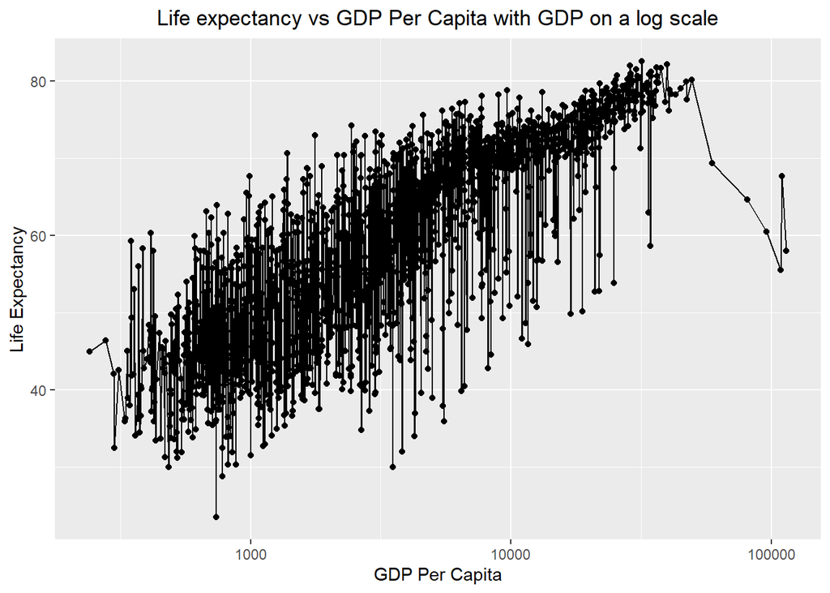

```r
gapminder %>%
  ggplot(aes(x = gdpPercap, y = lifeExp))+
  geom_point()+
  geom_line()+
  scale_x_log10()+
  labs(title = "Life expectancy vs GDP Per Capita with GDP on a log scale",
       x = "GDP Per Capita",
       y = "Life Expectancy")+
  theme(plot.title = element_text(hjust=0.5))
```

8. Which five countries have had the highest GDP per capita growth over the years represented in this dataset? Show this as a table.

*Because it’s a bit vague on what “highest GDP per capita growth over the years represented”, I’m interpreting this question as “the biggest change if you take the first and last values and take the difference.”*

*Using this definition, the countries are Singapore, Norway, Hong Kong (China), Ireland, and Austria.*

```r
gapminder %>%
  group_by(country) %>%
  summarize(
    first_gdp = first(gdpPercap, order_by = year),
    last_gdp = last(gdpPercap, order_by = year),
    gdp_diff = last_gdp - first_gdp
  ) %>%
  top_n(5) %>%
  arrange(-gdp_diff)
```

```
## # A tibble: 5 × 4
##   country          first_gdp last_gdp gdp_diff
##   <fct>                <dbl>    <dbl>    <dbl>
## 1 Singapore            2315.   47143.   44828.
## 2 Norway              10095.   49357.   39262.
## 3 Hong Kong, China     3054.   39725.   36671.
## 4 Ireland              5210.   40676.   35466.
## 5 Austria              6137.   36126.   29989.
```

9. How does per capita GDP growth compare between these same five countries? Show this as a plot.

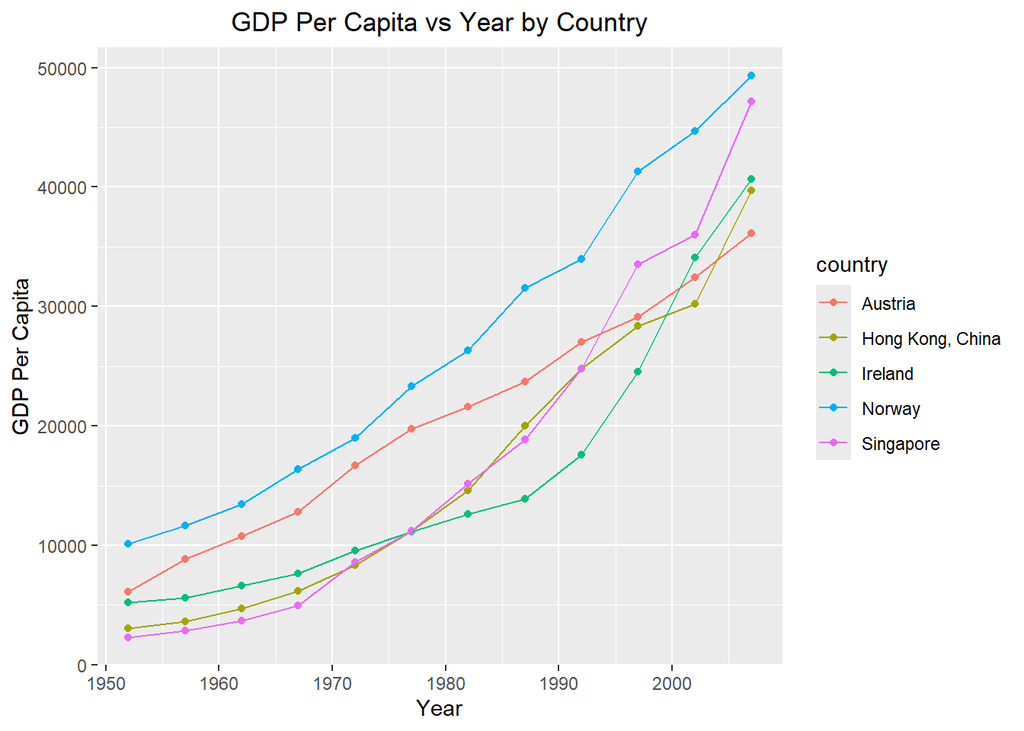

```r
gapminder %>%
  filter(country %in% c("Singapore", "Norway", "Hong Kong, China", "Ireland", "Austria")) %>%
  ggplot(aes(x = year, y = gdpPercap, color = country))+
  geom_point()+
  geom_line()+
  labs(
    title = "GDP Per Capita vs Year by Country",
    x = "Year",
    y = "GDP Per Capita"
  )+
  theme(plot.title = element_text(hjust= 0.5))
```

10. Do one analysis of your choice that includes a table and plot as outputs.

**Convert** `gdpPercap` **into categorical variables, and make a table of each year and how many countries fall into each category. Then, graph number of countries (y-axis) vs year (x-axis) grouped by each gdp category. What trends do you notice?**

*I notice that there seems to be a general uptick in countries with higher GDPs. Obviously, there will be some that aren’t in the highest quartiles, but in the overall data, it seems like it’s approaching roughly 42% of countries doing in the top 25% of all data (~60/142 countries, “high” gdp being the third quartile or higher).*

```r
library(gtools)
quartiles <- quantcut(gapminder$gdpPercap)
table(quartiles)
```

```
## quartiles
##       [241,1.2e+03]  (1.2e+03,3.53e+03] (3.53e+03,9.33e+03] (9.33e+03,1.14e+05]
##                 426                 426                 426                 426
```

```r
gapminder <- gapminder %>%
  mutate(gdp_category = case_when(gdpPercap < 1.2e+03 ~ "low",
                                  gdpPercap > 1.2e+03 & gdpPercap <= 3.53e+03 ~ "medium-low",
                                  gdpPercap > 3.53e+03 & gdpPercap <= 9.33e+03 ~ "medium-high",
                                  gdpPercap > 9.33e+03 ~ "high"))

gapminder %>%
  group_by(gdp_category, year) %>%
  summarize(
    n_countries = n_distinct(country),
    .groups='keep'
  ) %>%
  pivot_wider(
    names_from = gdp_category,
    values_from = n_countries
  )
```

```
## # A tibble: 12 × 5
## # Groups:   year [12]
##     year  high   low `medium-high` `medium-low`
##    <int> <int> <int>         <int>        <int>
##  1  1952    10    52            30           50
##  2  1957    15    43            37           47
##  3  1962    20    43            39           40
##  4  1967    25    37            38           42
##  5  1972    37    33            32           40
##  6  1977    45    33            31           33
##  7  1982    43    31            38           30
##  8  1987    43    31            38           30
##  9  1992    40    34            39           29
## 10  1997    45    32            35           30
## 11  2002    45    31            38           28
## 12  2007    57    25            33           27
```

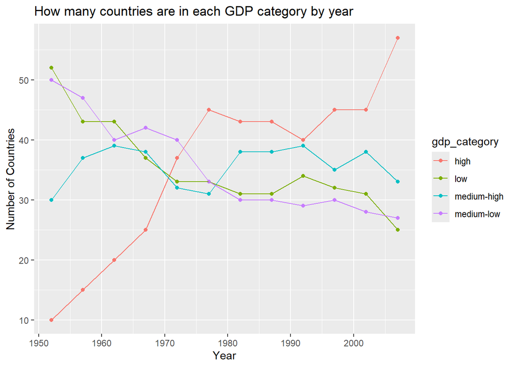

```r
gapminder %>%
  group_by(year, gdp_category) %>%
  summarize(n=n(), .groups='keep') %>%
  ggplot(aes(x=year, y = n, group = gdp_category, color = gdp_category))+
  geom_point()+
  geom_line()+
  labs(title = "How many countries are in each GDP category by year",
       x = "Year",
       y = "Number of Countries")
```

## Knit and Upload

Please knit your work as a .pdf or .html file and upload to Canvas. Homework is due before the start of the next lab. No late work is accepted. Make sure to use the formatting conventions of RMarkdown to make your report neat and clean!